# Peer asessment 2

Siqi Zhu

December 25, 2015

```r
library(ggplot2)
fileurl <- 'https://d396qusza40orc.cloudfront.net/exdata%2Fdata%2FNEI_data.zip'
setwd('/Users/zhusiqi/Desktop/coursera/R_jhu/exploratory_data_analysis/peer_assesment_2')
if (!file.exists('./exdata-data-NEI_data.zip')){
        download.file(fileurl,'./exdata-data-NEI_data.zip')
        unzip("exdata-data-NEI_data.zip", exdir = './')
}

NEI <- readRDS("./exdata-data-NEI_data/summarySCC_PM25.rds")
SCC <- readRDS("./exdata-data-NEI_data/Source_Classification_Code.rds")
```

### Question 1

Have total emissions from PM2.5 decreased in the United States from 1999 to 2008?

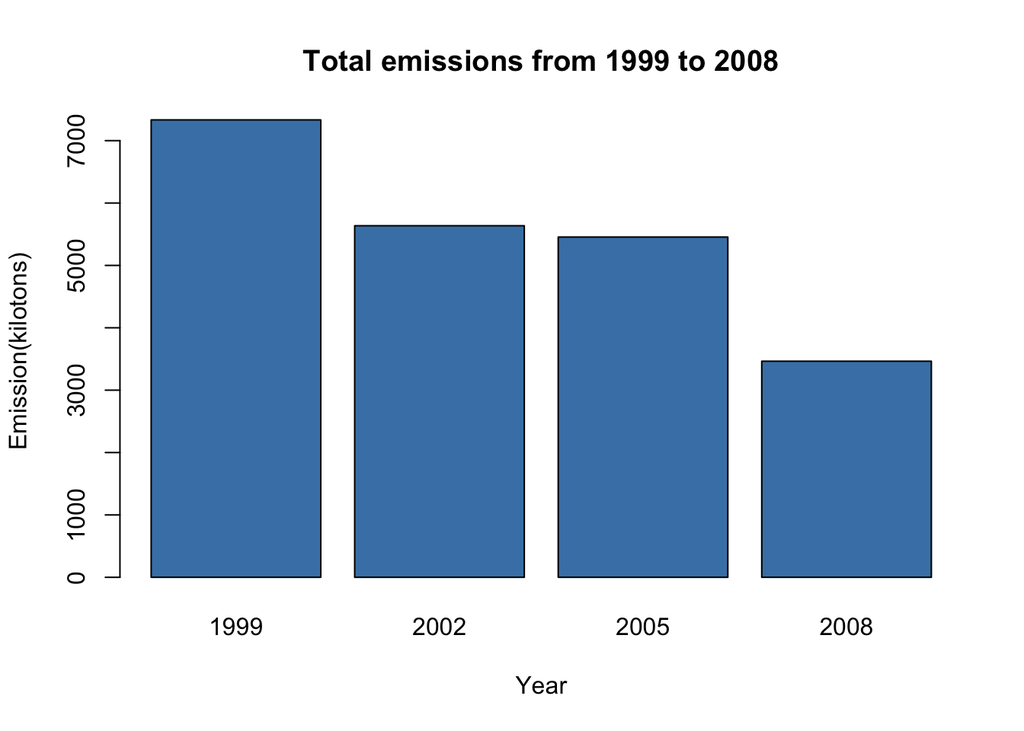

```r
Emissions.total <- aggregate(NEI$Emissions, list(year = NEI$year), sum)
names(Emissions.total) <- c('year', 'Emissions')
barplot(Emissions.total$Emissions/1000, names.arg =  Emissions.total$year, xlab = 'Year', ylab = 'Emission(kilotons)', main =  'Total emissions from 1999 to 2008', col = 'steelblue')
```

#### Answer:

Yes. As we can see from plot1, emissions decreased in the United States from 1999 to 2008.

### Question 2

Have total emissions from PM2.5 decreased in the Baltimore City, Maryland (fips == “24510”) from 1999 to 2008?

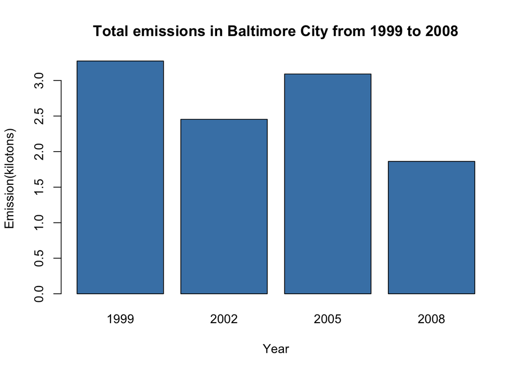

```r
Bal <- NEI[NEI$fips == '24510',]
Bal.total <- aggregate(Bal$Emissions, list(year = Bal$year), sum)
names(Bal.total) <- c('year', 'Emissions')
barplot(Bal.total$Emissions/1000, names.arg =  Bal.total$year, xlab = 'Year', ylab = 'Emission(kilotons)', main =  'Total emissions in Baltimore City from 1999 to 2008', col = 'steelblue')
```

#### Answer:

Emissions decreased on 2008 compared with 1999, although emissions increased from 2002 to 2005.

### Question 3

Of the four types of sources indicated by the type (point, nonpoint, onroad, nonroad) variable, which of these four sources have seen decreases in emissions from 1999–2008 for Baltimore City?

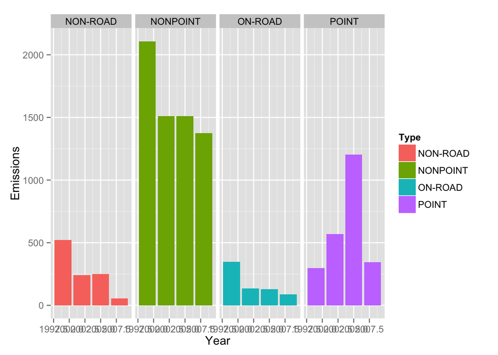

```r
Bal <- NEI[NEI$fips == '24510',]
Bal.type <- aggregate(Bal$Emissions, list(type = Bal$type, year = Bal$year), sum)
names(Bal.type) <- c('Type', 'Year', 'Emissions')
ggplot(data = Bal.type, aes(x = Year, y = Emissions, fill = Type)) + geom_histogram(stat = 'identity')+ facet_grid(.~Type)
```

#### Answer:

Non-road, nonpoint and on-road decreased from 1999 to 2008.

### Question 4

```r
combustion <- grepl("comb", SCC$SCC.Level.One, ignore.case=TRUE)
coal <- grepl("coal", SCC$SCC.Level.Three, ignore.case=TRUE)
coal_combustion <- combustion & coal
index <- SCC[coal_combustion, ]$SCC
US.relate <- NEI[NEI$SCC %in% index, ]
US.relate.sum <- aggregate(US.relate$Emissions, list(year = US.relate$year), sum)
names(US.relate.sum) <- c('Year', 'Emissions')
png(filename = "plot4.png")
ggplot(data = US.relate.sum, aes(x = Year, y = Emissions)) + geom_histogram(stat = 'identity', fill = 'steelblue') + labs(title = 'Emissions from coal combustion-related sources')
dev.off()
```

### Question 5

How have emissions from motor vehicle sources changed from 1999–2008 in Baltimore City?

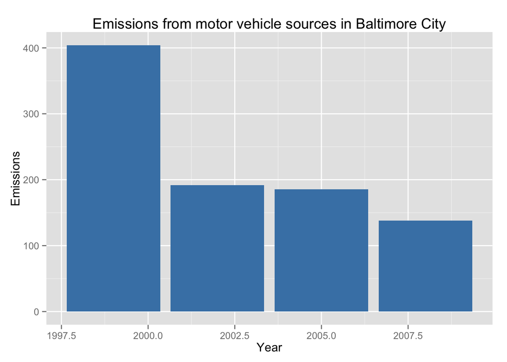

```r
motor <- grepl("vehicle", SCC$SCC.Level.Two, ignore.case=TRUE)
index <- SCC[motor, ]$SCC
Bal <- NEI[NEI$fips == '24510',]
Bal.relate <- Bal[Bal$SCC %in% index, ]
Bal.relate.sum <- aggregate(Bal.relate$Emissions, list(year = Bal.relate$year), sum)
names(Bal.relate.sum) <- c('Year', 'Emissions')
ggplot(data = Bal.relate.sum, aes(x = Year, y = Emissions)) + geom_histogram(stat = 'identity', fill = 'steelblue') + labs(title = 'Emissions from motor vehicle sources in Baltimore City')
```

#### Answer:

Emissions from motor vehicle sources decreased from 1999–2008 in Baltimore City.

### Question 6

Compare emissions from motor vehicle sources in Baltimore City with emissions from motor vehicle sources in Los Angeles County, California (fips == “06037”). Which city has seen greater changes over time in motor vehicle emissions?

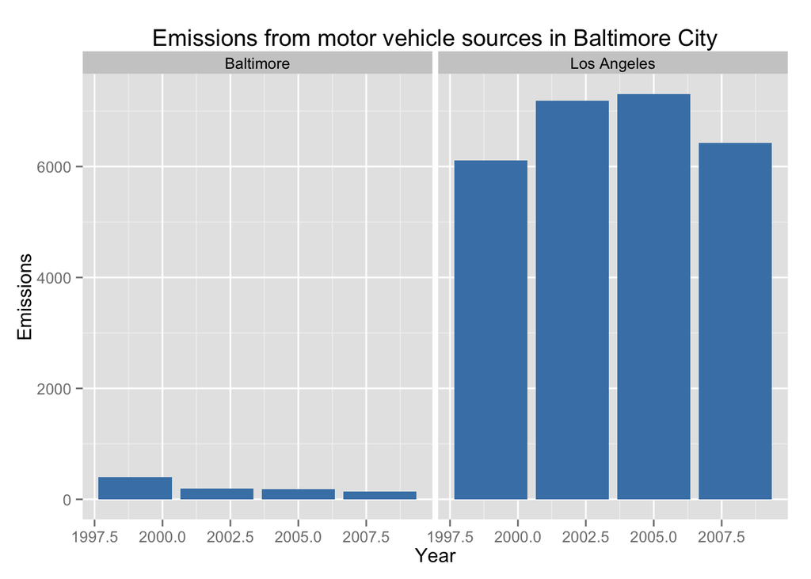

```r
motor <- grepl("vehicle", SCC$SCC.Level.Two, ignore.case=TRUE)
index <- SCC[motor, ]$SCC
Bal_los <- NEI[(NEI$fips == '24510'|NEI$fips == '06037'),]
Bal_los.motor <- Bal_los[Bal_los$SCC %in% index, ]
Bal_los.motor.sum <- aggregate(Bal_los.motor$Emissions, list(year = Bal_los.motor$year, fips = Bal_los.motor$fips), sum)
names(Bal_los.motor.sum) <- c('Year', 'fips', 'Emissions')
Bal_los.motor.sum$fips <- ifelse(Bal_los.motor.sum$fips == '06037', 'Los Angeles','Baltimore')
ggplot(data = Bal_los.motor.sum, aes(x = Year, y = Emissions)) + facet_grid(.~fips) + geom_histogram(stat = 'identity', fill = 'steelblue') + labs(title = 'Emissions from motor vehicle sources in Baltimore City')
```

#### Answer:

Los Angeles have larger volume of PM2.5 emissions from motor vehicle sources than Baltimore. Therefore, Los Angeles has seen greater changes over time in motor vehicle emissions.